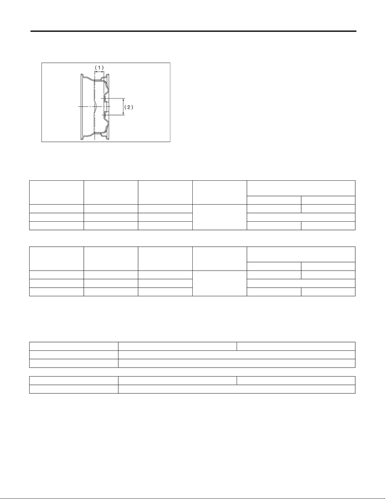

General Description

WHEEL AND TIRE SYSTEM

1. General Description

A: SPECIFICATION

• STI model

• Except for STI model

NOTE:

“Tire inflation pressure” label attached to the body side of the driver’s door.

1. SERVICE DATA

WT-00001

(1) Inset

(2) P.C.D.

Tire size Wheel size

Inset

mm (in)

P. C . D .

mm (in)

Tire inflation pressure kPa

Front wheel Rear wheel

245/40R18 97W 18 × 8

114.3 (4.50)

230 (2.3, 33) 220 (2.2, 32)

T145/70D17 106M 17 × 4T 30 (1.18) 420 (4.2, 60)

205/50R17 89V 17 × 7J 55 (2.17) — 230 (2.3, 33)

Tire size Wheel size

Inset

mm (in)

P. C . D .

mm (in)

Tire inflation pressure kPa

Front wheel Rear wheel

235/45R17 94W 17 × 8J 55 (2.17)

114.3 (4.50)

230 (2.3, 33) 220 (2.2, 32)

T145/70D17 106M 17 × 4T 30 (1.18) 420 (4.2, 60)

205/50R17 89V 17 × 7J 55 (2.17) — 230 (2.3, 33)

Part Axial runout Radial runout

Steel wheel 1.5 mm (0.059 in)

Aluminum wheel 1.0 mm (0.039 in)

Wheel balancing Standard Service limit

Dynamic unbalance 5 g (0.18 oz) or less

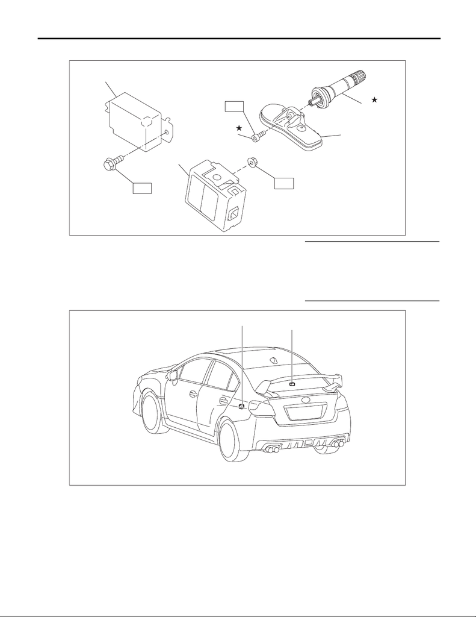

General Description

WHEEL AND TIRE SYSTEM

B: COMPONENT

(1) TPMS & keyless entry control

module (model with keyless entry)

(4) Transmitter (snap in type) Tightening torque: N·m (kgf-m, ft-lb)

(2) TPMS CM (model with keyless

access)

(5) Valve T1: 1.4 (0.1, 1.0)

(3) Screw T2: 7.5 (0.8, 5.5)

T3: 13 (1.3, 9.6)

(1) TPMS & keyless entry control

module (model with keyless entry)

(2) TPMS module ASSY (model with

keyless access)

WT-00210

T2

(4)

(3)

T1

(5)

(1)

T3

WT-00211

(2)

(1)

[figure not shown]

General Description

WHEEL AND TIRE SYSTEM

C: PREPARATION TOOL

1. GENERAL TOOL

TOOL NAME REMARKS

Air pressure gauge Used for measuring tire air pressure.

Dial gauge Used for measuring wheel runout.

Wheel balancer Used for adjusting wheel balance.